# PC GP2 02_C

## Percussion (2021-10-18)

- Pig = 35.5 kg
- Hole (max) 10.8 mm. 3 hits at 35 deg at 15:13 pm:
1. ICP from 9 to 28, at 5.22 atm.
2. ICP from 23 to 45, at 6.51 atm.
3. ICP from 26 to 35, at 7.2 atm.

## Cooling

Started at 3:19 pm.  
Brain temperature was 38 deg, cooled down to 33 deg (after 2h at 5:20pm).  
- At 11:45 pm, anterior temp probe malfunctioned.  
- At 12:30 am (next day), switched to posterior temp probe with a reading of 28 deg. ICP was 30 mmHg, put on heating blanket. CT perfusion was low but okay.

- Controller would not start and stuck at 166% (around 9:10 am).
- At 10:45 am, Lynn came in and unstuck the flange.
- Rewarmed at 11 am (next day).

Study ended at 3:15 pm, 24h post percussion.

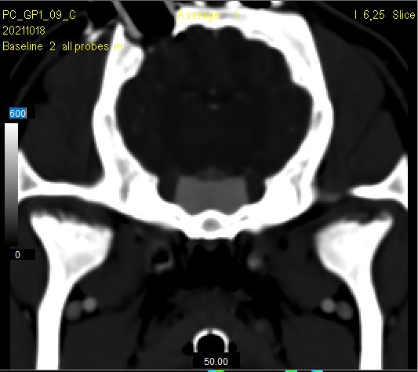

## Cooling set up

1st target = -11 deg (VT output air)  
Flow rate = 70 SLPM  
2nd target = 33 deg (brain temp to cool down to)  
Maintenance time = 1200 min (once brain reached 33 deg)  
3rd target temperature = 38.6 deg (rewarm target)  
Rewarm rate = 0.5 deg/h

# CT perfusion maps

Two phase acquisition:  
a) 1st phase: 40 images at 1.0s intervals  
b) 2nd phase: 10 images at 15s intervals

| Scan time | Description |
| --- | --- |
| 13:02 | Baseline before Drill |
| 14:41 | Baseline adaptor in |
| 15:30 | 15 min post |
| 15:45 | 30 min post |
| 16:15 | 60 min post |
| 16:46 | 90 min post |
| 17:16 | 2h post |
| 18:15 | 3h post |
| 19:16 | 4h post |
| 20:15 | 5h post |
| 21:15 | 6h post |
| 22:15 | 7h post |
| 23:16 | 8h post |
| 01:15 | 10h post |
| 03:15 | 12h post |
| 05:15 | 14h post |
| 07:15 | 16h post |
| 09:30 | 18h post |
| 11:00 | Rewarm |
| 11:15 | 20h post |
| 12:15 | 21h post |
| 13:15 | 22h post |
| 14:15 | 23h post |
| 15:15 | 24h post |

#### Blood flow maps

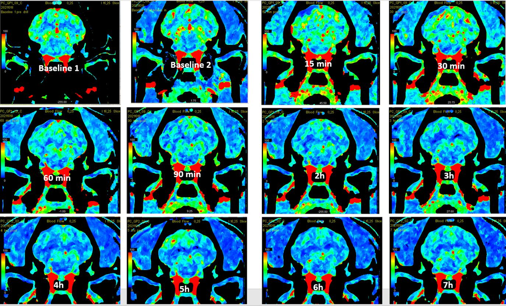

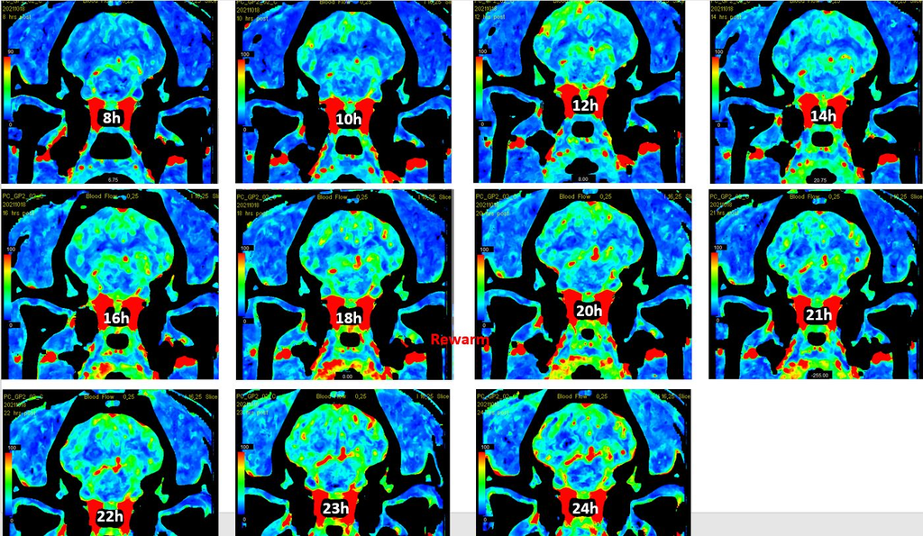

## Plots

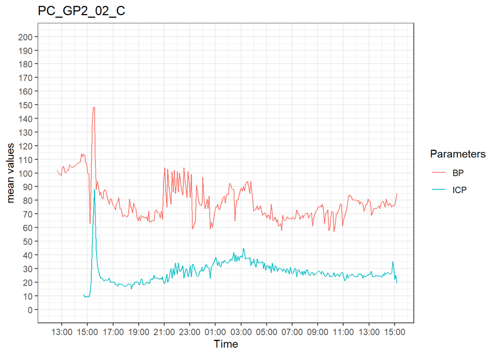

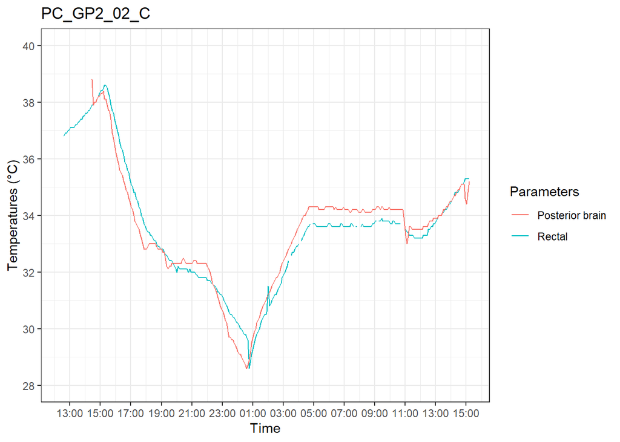

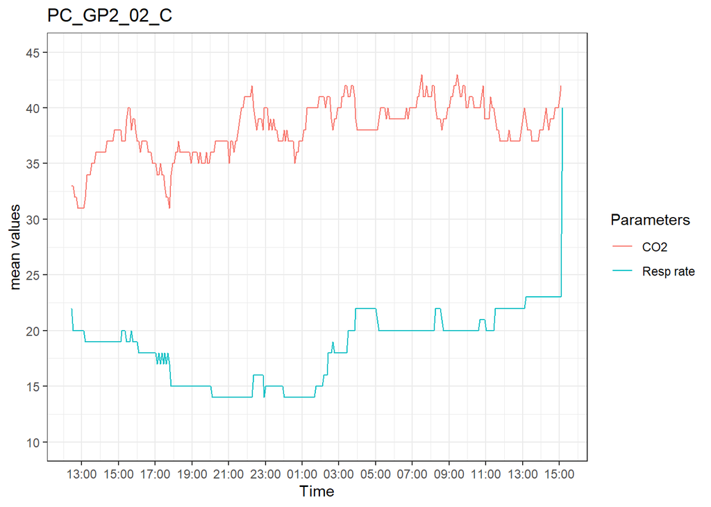

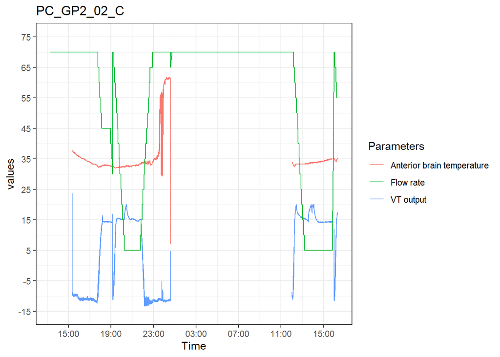

## TTC

[figure not shown]